# Aleksei Shokhirev / portfolio project 3

In this project we will analyze the marketing campaign for the online subscription business. Firstly, we will compute the common metrics such as conversion rate and retention rate. We will measure how the campaign performed for different marketing channels and across demographics. Secondly, we will check the accuracy of campaign performance and detecting bugs and their influence on the result. On the top of that, we will analyze A/B test and compute common metrics such as lift and t-statistics.

The marketing dataset contains following data:

- 'date_served' - date the marketing assets have been displayed;
- 'marketing_channel' - the type of marketing assets;
- 'converted' - True if the customer subscribed False otherwise;
- 'language_displayed' - the actual language of marketing assets;
- 'language_preferred' - the language of customer preference
- 'age_group' - the customer age group
- 'is_retained' - True if the customer keep using a product after free trail finished and False otherwise
- 'variant' - the A/B test result. Personalization means the customer received a personalized message. Control means generic upsells to the product.

# Read and explore data

```python
# import modules
import pandas as  pd
import numpy as np
import matplotlib.pyplot as plt
import seaborn as sns
import missingno as msno
from empiricaldist import Pmf
from scipy.stats import ttest_ind
```

```python
# read dataset
marketing = pd.read_csv('marketing.csv', parse_dates = [
    'date_served', 'date_subscribed', 'date_canceled'])
marketing.head(2)
```

|  | user_id | date_served | marketing_channel | variant | converted | language_displayed | language_preferred | age_group | date_subscribed | date_canceled | subscribing_channel | is_retained |
| --- | --- | --- | --- | --- | --- | --- | --- | --- | --- | --- | --- | --- |
| 0 | a100000029 | 2018-01-01 | House Ads | personalization | True | English | English | 0-18 years | 2018-01-01 | NaT | House Ads | True |
| 1 | a100000030 | 2018-01-01 | House Ads | personalization | True | English | English | 19-24 years | 2018-01-01 | NaT | House Ads | True |

```python
marketing.info()
```

```
<class 'pandas.core.frame.DataFrame'>
RangeIndex: 10037 entries, 0 to 10036
Data columns (total 12 columns):
 #   Column               Non-Null Count  Dtype
---  ------               --------------  -----
 0   user_id              10037 non-null  object
 1   date_served          10021 non-null  datetime64[ns]
 2   marketing_channel    10022 non-null  object
 3   variant              10037 non-null  object
 4   converted            10022 non-null  object
 5   language_displayed   10037 non-null  object
 6   language_preferred   10037 non-null  object
 7   age_group            10037 non-null  object
 8   date_subscribed      1856 non-null   datetime64[ns]
 9   date_canceled        577 non-null    datetime64[ns]
 10  subscribing_channel  1856 non-null   object
 11  is_retained          1856 non-null   object
dtypes: datetime64[ns](3), object(9)
memory usage: 941.1+ KB
```

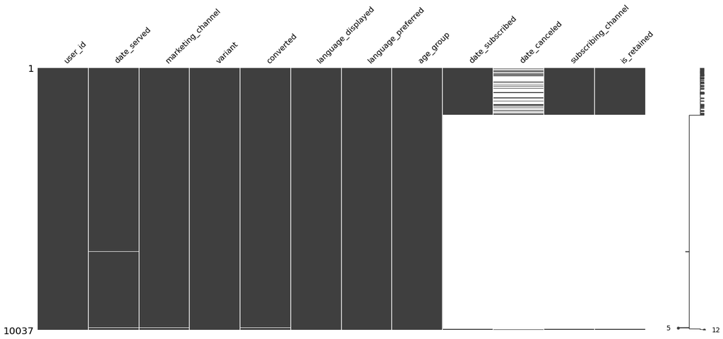

```python
# plot missing data
msno.matrix(marketing)
plt.show()
```

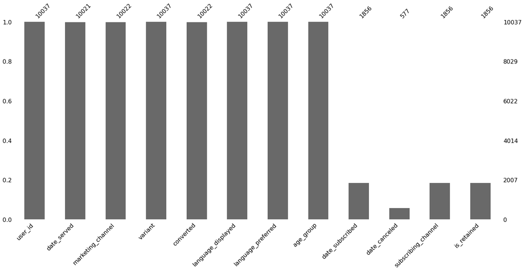

```python
msno.bar(marketing)
```

```python
# drop observations with NaN by date_served column
marketing.dropna(subset=['date_served'], inplace=True)
marketing.info()
```

```
<class 'pandas.core.frame.DataFrame'>
Int64Index: 10021 entries, 0 to 10036
Data columns (total 12 columns):
 #   Column               Non-Null Count  Dtype
---  ------               --------------  -----
 0   user_id              10021 non-null  object
 1   date_served          10021 non-null  datetime64[ns]
 2   marketing_channel    10021 non-null  object
 3   variant              10021 non-null  object
 4   converted            10021 non-null  object
 5   language_displayed   10021 non-null  object
 6   language_preferred   10021 non-null  object
 7   age_group            10021 non-null  object
 8   date_subscribed      1856 non-null   datetime64[ns]
 9   date_canceled        577 non-null    datetime64[ns]
 10  subscribing_channel  1856 non-null   object
 11  is_retained          1856 non-null   object
dtypes: datetime64[ns](3), object(9)
memory usage: 1017.8+ KB
```

```python
# check for duplicates
duplicates = marketing.duplicated(keep=False)
marketing[duplicates].shape[0]
```

```
74
```

```python
# drop duplicates
marketing.drop_duplicates(inplace=True)
```

# Feature engineering

```python
# create a column 'is_correct_lang'
marketing['is_correct_lang'] = np.where(marketing['language_displayed'] == marketing['language_preferred'], 'Yes', 'No')
```

# Functions

```python
# create functions
def users_by_metrics(df, columns):
    """Nuber of users across different metrics"""
    number_of_users = df.groupby(columns)['user_id'].nunique().unstack(level=1)
    return number_of_users

def plot_ads(axes, df, kind, title, ylabel):
    """Function for plotting retention and conversion rates"""
    df.plot(ax=axes, kind=kind, title=title, ylabel=ylabel, xlabel='')

def conversion_rate(df, columns):
    """Conversion rate function"""
    total = df.groupby(columns)['user_id'].nunique()
    converted = df[df['converted']==True].groupby(columns)['user_id'].nunique()
    conversion_rate = converted / total
    conversion_rate = conversion_rate.fillna(0)
    return conversion_rate

def retention_rate(df, columns):
    """Retention rate function"""
    converted = df[df['converted']==True].groupby(columns)['user_id'].nunique()
    retained = df[df['is_retained']==True].groupby(columns)['user_id'].nunique()
    retention_rate = retained / converted
    retention_rate = retention_rate.fillna(0)
    return retention_rate

def plot_metric(axes, df, kind):
    """Function for plotting retention and conversion rates"""
    df.plot(ax=axes, kind=kind, title=df.name, xlabel='')

def plot_metrics_time(df1, df2):
    """Function to plot metrics over time"""
    for c in df1.columns.values:
        plt.figure(figsize=[10, 4])
        plt.subplot(1, 2, 1)
        plt.plot(df1.index, df1[c])
        plt.title(df1.name + ' by '+ c)
        plt.xticks(rotation=45)

        plt.subplot(1, 2, 2)
        plt.plot(df2.index, df2[c])
        plt.title(df2.name + ' by ' + c)
        plt.xticks(rotation=45)
        plt.show()

def count_pmf_plot(df):
    """Count and Pmf plots"""
    for c in df.columns.values:
        pmf = Pmf.from_seq(df[c], normalize=True)

        plt.figure(figsize=[12, 4])
        plt.subplot(1, 2, 1)
        sns.countplot(data=df, x=c)
        plt.title(c)
        plt.ylabel('Number of users')
        plt.xlabel('')
        plt.xticks(rotation=30)

        plt.subplot(1, 2, 2)
        pmf.bar()
        plt.title('PMF ' + c)
        plt.ylabel('Fraction of users')
        plt.xlabel('')
        plt.xticks(rotation=30)
        plt.show()

def lift(control, personalization):
    """Function to compute the lift"""
    control_mean = np.mean(control)
    personalization_mean = np.mean(personalization)
    lift = (personalization_mean - control_mean)/control_mean
    return str(round(lift*100, 2)) + '%'

def ab_segmentation(channel, segment):
    """Lift and t-statistics across segments"""
    # iterate through each subsegment in marketing
    for subsegment in np.unique(marketing[segment].values):
        # limit marketing to email and subsegment
        df_channel = marketing[(marketing['marketing_channel']==channel)&(marketing[segment]==subsegment)]
        # ensure each user and variant has only one subscription outcome
        subscribers = df_channel.groupby(['user_id', 'variant'])['converted'].max().unstack(level=1)
        # isolate control and personalization
        control = subscribers['control'].dropna()
        personalization = subscribers['personalization'].dropna()
        # print conversion rate and statistical significance for each subsegment
        print(subsegment)
        print('lift: ', lift(control, personalization))
        print('t-statistics: ', ttest_ind(control, personalization), '\n')

def conversion_ab_test(channel):
    """Conversion rate for control and personalization across marketing channels"""
    # first, we ensure each user and variant has only one subscription outcome
    subscribers_df = marketing[marketing['marketing_channel']==channel].groupby(
    ['user_id', 'variant'])['converted'].max().unstack(level=1)
    # isolate subscription outcome for control and personalization groups
    control = subscribers_df['control'].dropna()
    personalization =subscribers_df['personalization'].dropna()
    # compute the conversion rate for both personalization and control
    control_rate = round(np.mean(control), 4)
    personalization_rate = round(np.mean(personalization), 4)
    return control_rate, personalization_rate

def conversion_ab_test_age(age):
    """Conversion rate for control and personalization across age groups"""
    # first, we ensure each user and variant has only one subscription outcome
    subscribers_df = marketing[marketing['age_group']==age].groupby(
    ['user_id', 'variant'])['converted'].max().unstack(level=1)
    # isolate subscription outcome for control and personalization groups
    control = subscribers_df['control'].dropna()
    personalization =subscribers_df['personalization'].dropna()
    # compute the conversion rate for both personalization and control
    control_rate = round(np.mean(control), 4)
    personalization_rate = round(np.mean(personalization), 4)
    return control_rate, personalization_rate

def allocation(channel):
    """Allocation control and personalization across marketing channels"""
    allocation = marketing[marketing['marketing_channel']==channel].groupby('variant')['user_id'].nunique()
    return allocation

def control_personalization(channel):
    """Extract control and personalization across marketing channels"""
    # first, we ensure each user and variant has only one subscription outcome
    subscribers = marketing[marketing['marketing_channel']==channel].groupby(
        ['user_id', 'variant'])['converted'].max().unstack(level=1)
    # isolate subscription outcome for control and personalization groups
    control = subscribers['control'].dropna()
    personalization =subscribers['personalization'].dropna()
    return control, personalization

def control_personalization_age(age):
    """Extract control and personalization across age groups"""
    # first, we ensure each user and variant has only one subscription outcome
    subscribers = marketing[marketing['age_group']==age].groupby(
        ['user_id', 'variant'])['converted'].max().unstack(level=1)
    # isolate subscription outcome for control and personalization groups
    control = subscribers['control'].dropna()
    personalization =subscribers['personalization'].dropna()
    return control, personalization

def conversion_ab_channels(channel):
    """Conversion rates for control and personalization, lift and t-statistics across channels"""
    control_rate, personalization_rate = conversion_ab_test(channel)
    control, personalization = control_personalization(channel)
    print(channel)
    print('Control conversion rate:', control_rate)
    print('Personalization conversion rate:', personalization_rate)
    print('lift: ', lift(control, personalization))
    print(ttest_ind(control, personalization), '\n\n')

def conversion_ab_age(age):
    """Conversion rates for control and personalization, lift and t-statistics across age groups"""
    control_rate, personalization_rate = conversion_ab_test_age(age)
    control, personalization = control_personalization_age(age)
    print(age)
    print('Control conversion rate:', control_rate)
    print('Personalization conversion rate:', personalization_rate)
    print('lift: ', lift(control, personalization))
    print(ttest_ind(control, personalization), '\n\n')
```

# Exploratory data analysis

First, we will check the distribution of the number of users, conversion rate and retention rate for the observed period. This is important to understand the number of daily users, daily conversion rate and daily retention rate.

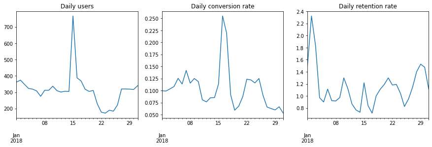

```python
# compute number of users who are seeing marketing assets each day
daily_users = marketing.groupby('date_served')['user_id'].nunique()
daily_users.name = 'Daily users'

# compute daily conversion rate
conversion_daily = conversion_rate(marketing, 'date_served')
conversion_daily.name = 'Daily conversion rate'

# compute daily retention rate
retention_daily = retention_rate(marketing, 'date_served')
retention_daily.name = 'Daily retention rate'

# plot all metrics
fig, axes = plt.subplots(1, 3, figsize = (15, 4))
plot_metric(axes[0], daily_users, 'line')
plot_metric(axes[1], conversion_daily, 'line')
plot_metric(axes[2], retention_daily, 'line')
plt.show()
```

```python
# make sure that only customers retained who converted first
users_error = marketing.query('converted==False and is_retained==True')
users_error.shape[0]
```

```
571
```

```python
# select only retained customers who converted first
marketing.drop(index=users_error.index, inplace=True)
marketing.info()
```

```
<class 'pandas.core.frame.DataFrame'>
Int64Index: 9413 entries, 0 to 10035
Data columns (total 13 columns):
 #   Column               Non-Null Count  Dtype
---  ------               --------------  -----
 0   user_id              9413 non-null   object
 1   date_served          9413 non-null   datetime64[ns]
 2   marketing_channel    9413 non-null   object
 3   variant              9413 non-null   object
 4   converted            9413 non-null   object
 5   language_displayed   9413 non-null   object
 6   language_preferred   9413 non-null   object
 7   age_group            9413 non-null   object
 8   date_subscribed      1274 non-null   datetime64[ns]
 9   date_canceled        575 non-null    datetime64[ns]
 10  subscribing_channel  1274 non-null   object
 11  is_retained          1274 non-null   object
 12  is_correct_lang      9413 non-null   object
dtypes: datetime64[ns](3), object(10)
memory usage: 1.0+ MB
```

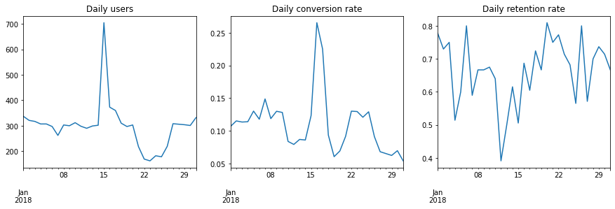

```python
# compute number of users who are seeing marketing assets each day
daily_users = marketing.groupby('date_served')['user_id'].nunique()
daily_users.name = 'Daily users'

# compute daily conversion rate
conversion_daily = conversion_rate(marketing, 'date_served')
conversion_daily.name = 'Daily conversion rate'

# compute daily retention rate
retention_daily = retention_rate(marketing, 'date_served')
retention_daily.name = 'Daily retention rate'

# plot all metrics
fig, axes = plt.subplots(1, 3, figsize = (15, 4))
plot_metric(axes[0], daily_users, 'line')
plot_metric(axes[1], conversion_daily, 'line')
plot_metric(axes[2], retention_daily, 'line')
plt.show()
```

We isolated 571 users for clarification with marketing team. Now we can clearly see the number of daily users, daily conversion rate and daily retention rate. As the next step we will check the distribution of marketing_channel, language_displayed and age_group variables.

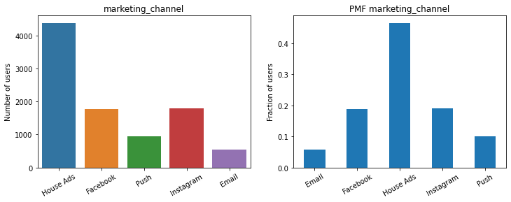

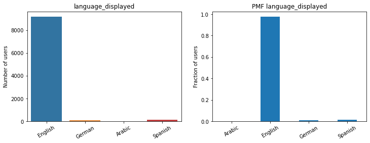

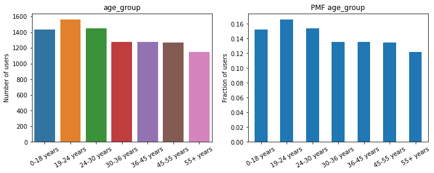

```python
# plot count and fraction for marketing_channel, Language displayed, Age group
count_pmf_plot(marketing[['marketing_channel', 'language_displayed', 'age_group']])
```

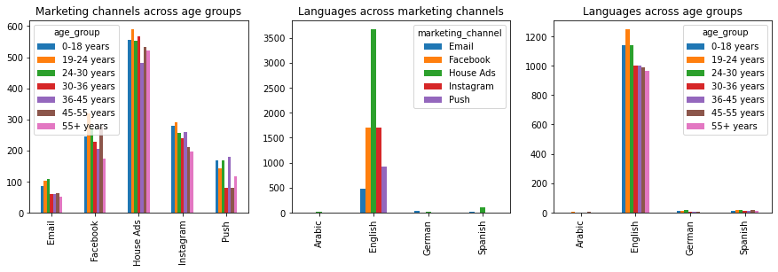

```python
# compute number of users for different combinations of
# marketing_channel, age_group and language_displayed
channel_age = users_by_metrics(marketing, ['marketing_channel', 'age_group'])
channel_age.name = 'Marketing channels across age groups'
language_channel = users_by_metrics(marketing, ['language_displayed', 'marketing_channel'])
language_channel.name = 'Languages across marketing channels'
language_age = users_by_metrics(marketing, ['language_displayed', 'age_group'])
language_age.name = 'Languages across age groups'

# plot all metrics
fig, axes = plt.subplots(1, 3, figsize = (15, 4))
plot_metric(axes[0], channel_age, 'bar')
plot_metric(axes[1], language_channel, 'bar')
plot_metric(axes[2], language_age, 'bar')
plt.show()
```

# Conversion and retention rates

Conversion rate is the percentage of users who saw the marketing assets and subsequently become subscribers. Conversion rate is one of the best ways to determine how effective a marketing team was at gaining new customers. Retention rate is the number of remaining subscribers from the users who converted to the company product. Retention rate can give a sense of whether the marketing campaign converted subscribers who are actually interested in the product. We will compute overall conversion and retention rates as well as conversion and retention rates across demographics and marketing channels.

```python
# compute overall conversion rate
total_conversion = marketing['user_id'].nunique()
subscribers_conversion = marketing[marketing['converted']==True]['user_id'].nunique()
conversion_overall = subscribers_conversion / total_conversion

# compute retention rate
total_retention = marketing[marketing['converted']==True]['user_id'].nunique()
subscribers_retention = marketing[marketing['is_retained']==True]['user_id'].nunique()
retention_overall = subscribers_retention / total_retention

# print the results
print('Overall conversion rate:', round(conversion_overall*100, 2), '%')
print('Overall retention rate:', round(retention_overall*100, 2), '%')
```

```
Overall conversion rate: 13.96 %
Overall retention rate: 64.53 %
```

```python
# compute conversion rate by marketing_channel, language_displayed, age_group
conversion_channel = conversion_rate(marketing, 'marketing_channel')
conversion_channel.name = 'Conversion rate by marketing channel'
conversion_language = conversion_rate(marketing, 'language_displayed')
conversion_language.name = 'Conversion rate by language displayed'
conversion_age = conversion_rate(marketing, 'age_group')
conversion_age.name = 'Conversion rate by age group'

# compute retention rate by marketing_channel, language_displayed, age_group
retention_channel = retention_rate(marketing, 'marketing_channel')
retention_channel.name = 'Retention rate by marketing channel'
retention_language = retention_rate(marketing, 'language_displayed')
retention_language.name = 'Retention rate by language displayed'
retention_age = retention_rate(marketing, 'age_group')
retention_age.name = 'Retention rate by age group'
```

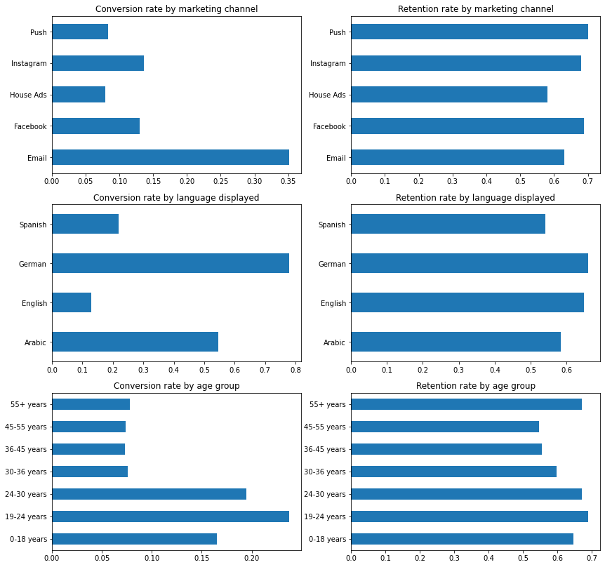

```python
# Plot conversion and retention rates
fig, axes = plt.subplots(3, 2, figsize=(14, 14))
plot_metric(axes[0, 0], conversion_channel, 'barh')
plot_metric(axes[0, 1], retention_channel, 'barh')
plot_metric(axes[1, 0], conversion_language, 'barh')
plot_metric(axes[1, 1], retention_language, 'barh')
plot_metric(axes[2, 0], conversion_age, 'barh')
plot_metric(axes[2, 1], retention_age, 'barh')
plt.show()
```

The marketing assets in German converted users the most effectively, but English has the lowest conversion rate. When it comes to retention rate, German and English are the most effective languages.

The age group of 19-24 years has the highest conversion rate or about 25%. Also, we can see that users who are younger than 30 years converted much better than 30+ year users. 55+ years and 19-24 years groups have the highest retention rates or around 65%. 45-55 years and 36-45 years group have the lowest retention rates or about 57%.

```python
# compute conversion rate by marketing_channel,
# language_displayed, age_group over time
conv_chann_time = conversion_rate(marketing, ['date_served', 'marketing_channel']).unstack(level=1)
conv_chann_time.name = 'Conversion rate'
conv_lang_time = conversion_rate(marketing, ['date_served', 'language_displayed']).unstack(level=1)
conv_lang_time.name = 'Conversion rate'
conv_age_time = conversion_rate(marketing, ['date_served', 'age_group']).unstack(level=1)
conv_age_time.name = 'Conversion rate'

# compute retention rate by marketing_channel,
# language_displayed, age_group over time
reten_chann_time = retention_rate(marketing, ['date_served', 'marketing_channel']).unstack(level=1)
reten_chann_time.name = 'Retention rate'
reten_lang_time = retention_rate(marketing, ['date_served', 'language_displayed']).unstack(level=1)
reten_lang_time.name = 'Retention rate'
reten_age_time = retention_rate(marketing, ['date_served', 'age_group']).unstack(level=1)
reten_age_time.name = 'Retention rate '
```

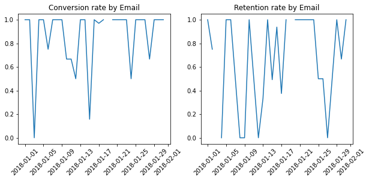

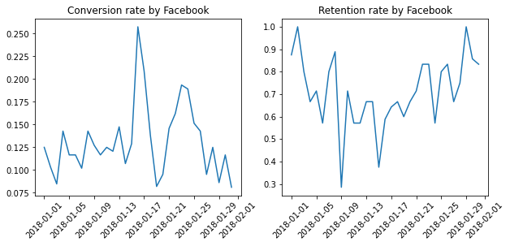

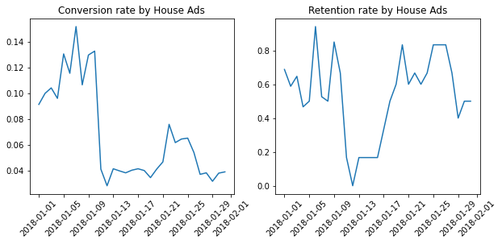

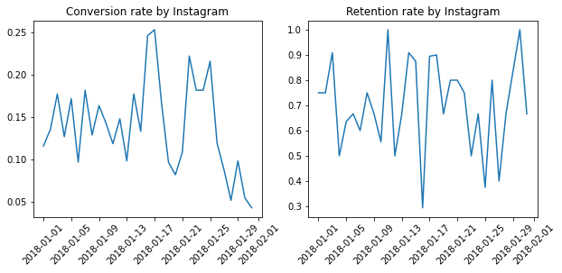

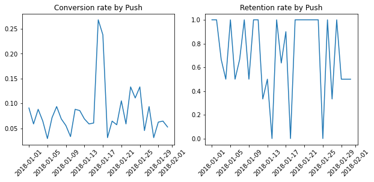

```python
# plot conversion and retention rates by marketing channel over time
plot_metrics_time(conv_chann_time, reten_chann_time)
```

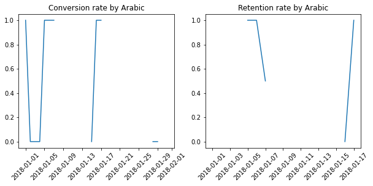

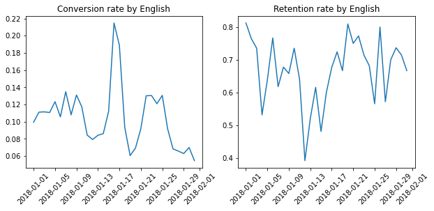

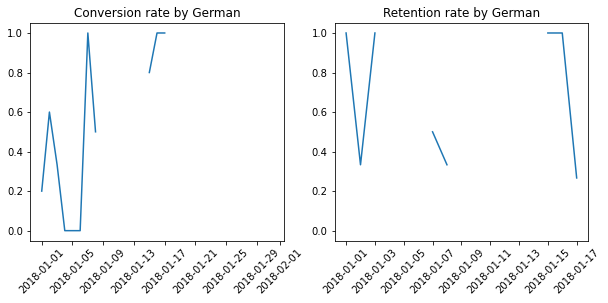

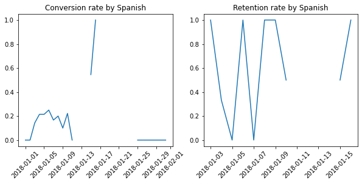

```python
# plot conversion and retention rates by language displayed over time
plot_metrics_time(conv_lang_time, reten_lang_time)
```

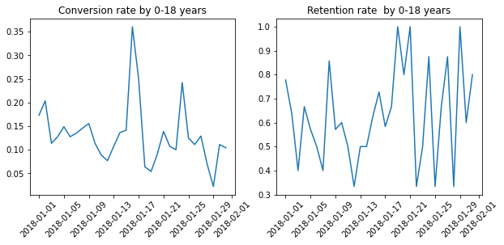

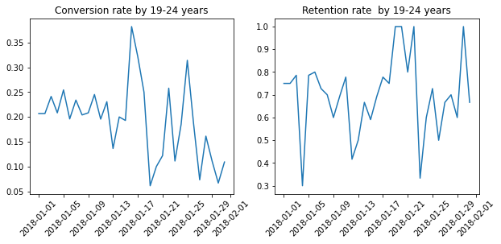

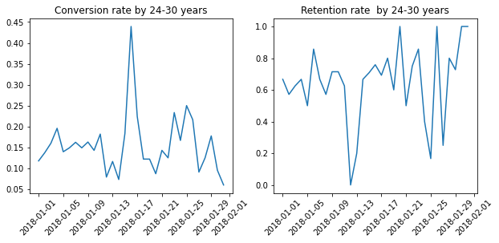

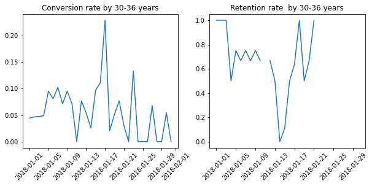

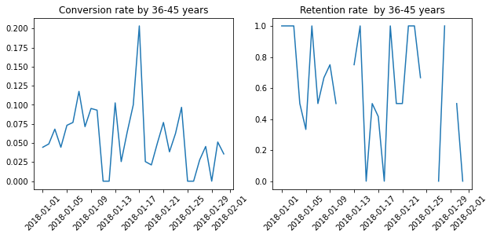

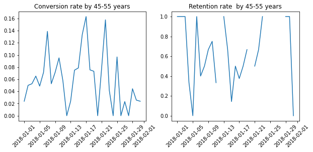

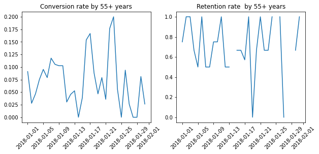

```python
# plot conversion and retention rates by age group over time
plot_metrics_time(conv_age_time, reten_age_time)
```

# Detecting a bug in the campaign implementation

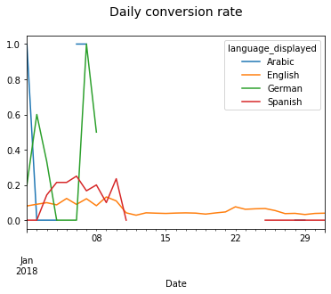

```python
# isolate the rows where marketing channel is House Ads
house_ads = marketing[marketing['marketing_channel'] == 'House Ads']

# calculate the daily conversion rate across languages
conv_lang_channel = conversion_rate(house_ads, ['date_served', 'language_displayed']).unstack(level=1)

# plot the daily conversion rates
conv_lang_channel.plot()
plt.title('Daily conversion rate\n', size=14)
plt.xlabel('Date')
plt.show()
```

As we can see, the English conversion rate dropped around 11th, and there do not appear to be ads served in other languages for more than two-week period. Now, we will compute the number of ads displayed in not correct language, and percentage of ads in the right language.

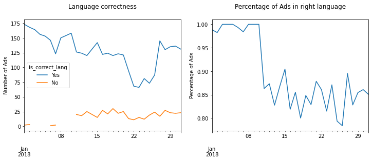

```python
# compute the number of ads displayed in not correct language
language_check = house_ads.groupby(['date_served', 'is_correct_lang'])['marketing_channel'].count().unstack(level=1)


# compute the percentage of Ads in right language
language_check['pct'] = language_check['Yes']/language_check.sum(axis=1)

# plot the result
fig, ax = plt.subplots(1, 2, figsize=(12, 4))
plot_ads(ax[0], language_check[['Yes', 'No']], 'line', 'Language correctness\n', 'Number of Ads')
plot_ads(ax[1], language_check['pct'], 'line', 'Percentage of Ads in right language\n', 'Percentage of Ads')
plt.show()
```

According to the chars, after the 11th of January around 25 ads or 12 % have been displayed in the not correct language each day.

# Lost subscribers

Now, we will calculate the number of subscribers the company lost as a result of the bug.

```python
# isolate data prior the bug occurred
house_ads_no_bag = house_ads[house_ads['date_served'] < '2018-01-11']

# compute conversion rate for each language during that period
lang_conv = conversion_rate(house_ads_no_bag, 'language_displayed')
lang_conv
```

```
language_displayed
Arabic     0.500000
English    0.105655
German     0.444444
Spanish    0.180851
Name: user_id, dtype: float64
```

```python
# compute the index of the other language conversion rates against English
spanish_index = lang_conv['Spanish'] / lang_conv['English']
arabic_index = lang_conv['Arabic'] / lang_conv['English']
german_index = lang_conv['German'] / lang_conv['English']

# print indices
print('Spanish index:', round(spanish_index, 2))
print('Arabic index:', round(arabic_index, 2))
print('German index:', round(german_index, 2))
```

```
Spanish index: 1.71
Arabic index: 4.73
German index: 4.21
```

Those indices reflect the relative relationship of how well the marketing assets typically convert users for each language compared to English. As we can see, Spanish speaking users typically convert at 1.71 times the rate of English speakers. Arabic and German speakers convert at about 4.73 and 4.21 times the rate of English speakers respectively. Now, that we have created indices for each language compared to English, we can assess what the conversion rate should have been during the rest of the month. To understand the true impact of the bug, it is crucial to determine how many subscribers we would have expected if no language error occurred.

```python
# compute the expected number of subscribers
converted = house_ads.groupby(['date_served', 'language_preferred']).agg(
    {'user_id':'nunique', 'converted':'sum'}).unstack(level=1)

# create English conversion rate for the rest of the month
converted['english_conv_rate'] = converted.loc['2018-01-11':'2018-01-31'][('converted', 'English')]/converted.loc['2018-01-11':'2018-01-31'][('user_id', 'English')]

# calculate daily expected conversion rate for each language
converted['expected_spanish_rate'] = converted['english_conv_rate']*spanish_index
converted['expected_arabic_rate'] = converted['english_conv_rate']*arabic_index
converted['expected_german_rate'] = converted['english_conv_rate']*german_index


# compute daily expected subscribers
converted['expected_spanish_subs'] = converted[('user_id', 'Spanish')]*converted['expected_spanish_rate']
converted['expected_arabic_subs'] = converted[('user_id', 'Arabic')]*converted['expected_arabic_rate']
converted['expected_german_subs'] = converted[('user_id', 'German')]*converted['expected_german_rate']

# print the expected subscribers across languages
converted[['expected_spanish_subs', 'expected_arabic_subs', 'expected_german_subs']].tail(2)
```

| language_preferred date_served | expected_spanish_subs | expected_arabic_subs | expected_german_subs |
| --- | --- | --- | --- |
| 2018-01-30 | 0.811481 | 0.560876 | 0.373918 |
| 2018-01-31 | 0.802367 | 1.03521 | 0.525822 |

Now, we will assess how many subscribers we lost due to the language discrepancy.

```python
# isolate days when the bug occurred
converted_bag = converted.loc['2018-01-11':'2018-01-31']

# sum expected subscribers for each language
expected_subs = converted_bag['expected_spanish_subs'].sum()+converted_bag['expected_arabic_subs'].sum()+converted_bag['expected_german_subs'].sum()

# sum actual subscribers
actual_subs = converted_bag[('converted', 'Spanish')].sum()+converted_bag[('converted', 'Arabic')].sum()+converted_bag[('converted', 'German')].sum()

# compute lost subscribers
lost_subs = expected_subs - actual_subs
print('Lost subscribers:', round(lost_subs, 0))
```

```
Lost subscribers: 24.0
```

We lost 24 potential subscribers.

# A/B test analysis

The marketing campaign was run as A/B test. Around half of the marketing messages were generic upsells to the product while the other half contained personalized messaging around the users` behavior on the site. Before we begin analyzing the results, we will check to ensure users were allocated equally to the test and control groups.

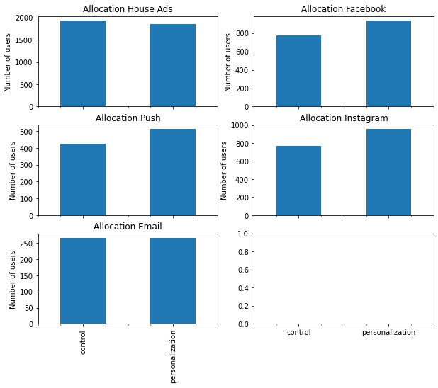

```python
# compute and plot allocations across marketing channels
alloc_house_ads = allocation('House Ads')
alloc_facebook = allocation('Facebook')
alloc_push = allocation('Push')
alloc_inst = allocation('Instagram')
alloc_email = allocation('Email')

fig, ax = plt.subplots(3, 2, figsize=(10, 8), sharex=True)
plot_ads(ax[0, 0], alloc_house_ads, 'bar', 'Allocation House Ads', 'Number of users')
plot_ads(ax[0, 1], alloc_facebook, 'bar', 'Allocation Facebook', 'Number of users')
plot_ads(ax[1, 0], alloc_push, 'bar', 'Allocation Push', 'Number of users')
plot_ads(ax[1, 1], alloc_inst, 'bar', 'Allocation Instagram', 'Number of users')
plot_ads(ax[2, 0], alloc_email, 'bar', 'Allocation Email', 'Number of users')
plt.show()
```

Allocations for House Ads and Email are relatively even, but not exactly the same. But there are differences in allocations for Push, Facebook and Instagram. We can clearly see more personalization messaging compared with the control for those tree channels. Now, we will compute conversion rates for the control and personalization groups. We will evaluate whether the conversion was higher in the personalization treatment compared with the control.

# Overall conversion rates, lift and t-statistics for control and personalization groups

Now, we will calculate overall conversion rate for control and personalization groups and lift. Lift means if the conversion rate was higher for the treatment and by how much. Also, we compute t-statistics by performing t-test. T-test allows to find out if the result of A/B test is statistically significant and can be used to make business decisions.

```python
# compute overall conversion rate for control and personalization groups
subscribers_ab = marketing.groupby(['user_id', 'variant'])['converted'].max().unstack(level=1)
control = subscribers_ab['control'].dropna()
personalization = subscribers_ab['personalization'].dropna()
print('Overall control conversion rate:', round(np.mean(control), 4))
print('Overall personalization conversion rate:', round(np.mean(personalization), 4))
print('lift:', lift(control, personalization))
print(ttest_ind(control, personalization))
```

```
Overall control conversion rate: 0.099
Overall personalization conversion rate: 0.1691
lift: 70.81%
Ttest_indResult(statistic=-8.873395769885624, pvalue=8.747611948132341e-19)
```

We can clearly see that personalization converted users at around 71% higher rate than the control. Moreover, p-value is less than 0.05 which means that the result is statistically significant and can be used for developing a marketing strategy.

# Conversion rates, lift and t-statistics across marketing channels

```python
for channel in marketing['marketing_channel'].unique():
    conversion_ab_channels(channel)
```

```
House Ads
Control conversion rate: 0.0888
Personalization conversion rate: 0.0683
lift:  -23.17%
Ttest_indResult(statistic=2.3500839799293676, pvalue=0.018820323083227203)


Facebook
Control conversion rate: 0.0593
Personalization conversion rate: 0.1915
lift:  223.03%
Ttest_indResult(statistic=-8.213009180643544, pvalue=4.1983177810594993e-16)


Push
Control conversion rate: 0.0307
Personalization conversion rate: 0.1287
lift:  318.62%
Ttest_indResult(statistic=-5.441986996224183, pvalue=6.73381035336805e-08)


Instagram
Control conversion rate: 0.0481
Personalization conversion rate: 0.2134
lift:  344.08%
Ttest_indResult(statistic=-10.134631494271167, pvalue=1.7388970984772504e-23)


Email
Control conversion rate: 0.2846
Personalization conversion rate: 0.4173
lift:  46.6%
Ttest_indResult(statistic=-3.233881374218041, pvalue=0.0012971299845076245)
```

The negative lift value for House Ads indicates that the control converted users better than personalized messaging. The rest of the channels shows that the personalization converted users more effectively than the control. The results for all marketing channels are statistically significant and can be used for making business decisions.

# Conversion rates, lift and t-statistics across age groups

```python
for age in marketing['age_group'].unique():
    conversion_ab_age(age)
```

```
0-18 years
Control conversion rate: 0.0894
Personalization conversion rate: 0.2316
lift:  159.14%
Ttest_indResult(statistic=-6.616005255443873, pvalue=5.6210760850649476e-11)


19-24 years
Control conversion rate: 0.0907
Personalization conversion rate: 0.3437
lift:  278.73%
Ttest_indResult(statistic=-10.989216547960433, pvalue=6.576082479686158e-27)


24-30 years
Control conversion rate: 0.0941
Personalization conversion rate: 0.2737
lift:  190.79%
Ttest_indResult(statistic=-7.883160995839712, pvalue=7.252855147185902e-15)


30-36 years
Control conversion rate: 0.1037
Personalization conversion rate: 0.0494
lift:  -52.36%
Ttest_indResult(statistic=3.2681364825964105, pvalue=0.0011189021422551202)


36-45 years
Control conversion rate: 0.0984
Personalization conversion rate: 0.0494
lift:  -49.8%
Ttest_indResult(statistic=2.9922855956435734, pvalue=0.002836139727195091)


45-55 years
Control conversion rate: 0.0984
Personalization conversion rate: 0.0514
lift:  -47.79%
Ttest_indResult(statistic=2.853071798441917, pvalue=0.0044180986062055455)


55+ years
Control conversion rate: 0.103
Personalization conversion rate: 0.0566
lift:  -45.01%
Ttest_indResult(statistic=2.696088270239073, pvalue=0.007136647408583217)
```

As we can see, the lift for users of age 30 years and older is negative which means the control conversion rate is higher than the personalization conversion rate and those users prefer not personalized marketing messages. On the other hand, users who are younger than 30 years prefer personalized messages. P-values are less than 0.05 across all age groups which means the results are statistically significant and can be used in marketing purposes.

# Lift and t-statistics across age groups for each channel

Now, we will break down results by various demographics and calculate lift and statistical significance across multiple segments of users.

```python
# compute lift and t-statistics across age groups for House Ads
ab_segmentation('House Ads', 'age_group')
```

```
0-18 years
lift:  34.4%
t-statistics:  Ttest_indResult(statistic=-1.18196343584882, pvalue=0.23772820472891876)

19-24 years
lift:  51.68%
t-statistics:  Ttest_indResult(statistic=-1.6675857248207269, pvalue=0.09592953369580264)

24-30 years
lift:  8.48%
t-statistics:  Ttest_indResult(statistic=-0.32386149796917374, pvalue=0.7461660094870555)

30-36 years
lift:  -73.79%
t-statistics:  Ttest_indResult(statistic=3.285667169099888, pvalue=0.0010804731120653088)

36-45 years
lift:  -70.83%
t-statistics:  Ttest_indResult(statistic=3.182996014511525, pvalue=0.001552197453518082)

45-55 years
lift:  -64.27%
t-statistics:  Ttest_indResult(statistic=2.5904183949157686, pvalue=0.009848793842147282)

55+ years
lift:  -65.99%
t-statistics:  Ttest_indResult(statistic=2.730434129845881, pvalue=0.006539717740655957)
```

The results for the House Ads channel indicate that age groups 0-18 years, 19-24 years and 24-30 years are not statistically significant and cannot be used for making business decisions. The rest of the age groups shows statistically significant results and the lifts with negative values which means the control converted users better than personalized messaging.

```python
# compute lift and t-statistics across age groups for Facebook
ab_segmentation('Facebook', 'age_group')
```

```
0-18 years
lift:  327.95%
t-statistics:  Ttest_indResult(statistic=-4.415601254106234, pvalue=1.5166462000108141e-05)

19-24 years
lift:  576.19%
t-statistics:  Ttest_indResult(statistic=-6.3309130281591015, pvalue=8.322992060226124e-10)

24-30 years
lift:  681.82%
t-statistics:  Ttest_indResult(statistic=-6.032048314986266, pvalue=5.290728792632324e-09)

30-36 years
lift:  10.09%
t-statistics:  Ttest_indResult(statistic=-0.21164578143938648, pvalue=0.8325732873700245)

36-45 years
lift:  -36.27%
t-statistics:  Ttest_indResult(statistic=0.8208347217842253, pvalue=0.41269857289098266)

45-55 years
lift:  -13.98%
t-statistics:  Ttest_indResult(statistic=0.2277343822472561, pvalue=0.8200225848992171)

55+ years
lift:  -8.55%
t-statistics:  Ttest_indResult(statistic=0.18071675257359116, pvalue=0.8568014395949484)
```

The results for the Facebook channel show that outcomes for all users older than 30 years are not statistically significant. Positive lifts indicate that users who are up to 30 years prefer personalized messages.

```python
# compute lift and t-statistics across age groups for Push
ab_segmentation('Push', 'age_group')
```

```
0-18 years
lift:  716.89%
t-statistics:  Ttest_indResult(statistic=-3.5710715215304565, pvalue=0.0004660540083737185)

19-24 years
lift:  694.05%
t-statistics:  Ttest_indResult(statistic=-3.842541112886334, pvalue=0.00018401593073427727)

24-30 years
lift:  600.0%
t-statistics:  Ttest_indResult(statistic=-4.048015867702671, pvalue=7.887245838812719e-05)

30-36 years
lift:  -67.21%
t-statistics:  Ttest_indResult(statistic=1.19975627725454, pvalue=0.23381978502678272)

36-45 years
lift:  95.6%
t-statistics:  Ttest_indResult(statistic=-0.5602073590335133, pvalue=0.5760423757999142)

45-55 years
lift:  14.29%
t-statistics:  Ttest_indResult(statistic=-0.12187048809143385, pvalue=0.9033110621688037)

55+ years
lift:  77.42%
t-statistics:  Ttest_indResult(statistic=-0.6845242358509179, pvalue=0.4950214298815363)
```

The results for the Push channel represent statistically significant outcomes only for user younger than 30 years. All of them prefer personalized messaging due to positive lifts. The result for the rest of the age groups are not statistically significant and cannot be used for making business decisions.

```python
# compute lift and t-statistics across age groups for Instagram
ab_segmentation('Instagram', 'age_group')
```

```
0-18 years
lift:  478.61%
t-statistics:  Ttest_indResult(statistic=-4.159656432166541, pvalue=4.2558734350491374e-05)

19-24 years
lift:  901.07%
t-statistics:  Ttest_indResult(statistic=-8.393962903510271, pvalue=2.125812678366425e-15)

24-30 years
lift:  488.54%
t-statistics:  Ttest_indResult(statistic=-5.446853208521666, pvalue=1.2062609159491367e-07)

30-36 years
lift:  146.73%
t-statistics:  Ttest_indResult(statistic=-1.5667107161577192, pvalue=0.11851651888581821)

36-45 years
lift:  129.36%
t-statistics:  Ttest_indResult(statistic=-1.7106991071400204, pvalue=0.08834337198395334)

45-55 years
lift:  12.5%
t-statistics:  Ttest_indResult(statistic=-0.25172908390522875, pvalue=0.8014966505958578)

55+ years
lift:  -40.63%
t-statistics:  Ttest_indResult(statistic=1.0104260929827982, pvalue=0.31353693666014654)
```

The results for the Instagram channel show statistically significant outcomes only for user younger than 30 years. All of them prefer personalized messaging due to positive lifts. The result for the rest of the age groups are not statistically significant and cannot be used for making business decisions.

```python
# compute lift and t-statistics across age groups for Email
ab_segmentation('Email', 'age_group')
```

```
0-18 years
lift:  119.38%
t-statistics:  Ttest_indResult(statistic=-2.983693771314711, pvalue=0.003716913460533689)

19-24 years
lift:  107.27%
t-statistics:  Ttest_indResult(statistic=-3.100131669901015, pvalue=0.0025007677130044086)

24-30 years
lift:  192.37%
t-statistics:  Ttest_indResult(statistic=-4.629994647198276, pvalue=1.0420109093895913e-05)

30-36 years
lift:  -100.0%
t-statistics:  Ttest_indResult(statistic=3.108217648291791, pvalue=0.002934875346242667)

36-45 years
lift:  -83.88%
t-statistics:  Ttest_indResult(statistic=2.2908319794601684, pvalue=0.02556247452671986)

45-55 years
lift:  -69.7%
t-statistics:  Ttest_indResult(statistic=1.9088396801063536, pvalue=0.06106914323150137)

55+ years
lift:  -100.0%
t-statistics:  Ttest_indResult(statistic=3.2522181779399553, pvalue=0.0020540219888878033)
```

The results for the Email channel show statistically significant outcomes for all age groups except the group of 45-55 years. Positive lifts indicate that users of age younger than 30 years prefer personalized messages but the control converted users older than 30 years much better than the personalized marketing assets.

# Lift and t-statistics across languages for each channel

```python
# check the size of classes for Instagram
marketing[marketing['marketing_channel']=='Instagram'].groupby(['language_displayed']).size()
```

```
language_displayed
English    1788
dtype: int64
```

```python
# check the size of classes for Facebook
marketing[marketing['marketing_channel']=='Facebook'].groupby(['language_displayed']).size()
```

```
language_displayed
English    1762
German        3
dtype: int64
```

```python
# check the size of classes for Push
marketing[marketing['marketing_channel']=='Push'].groupby(['language_displayed']).size()
```

```
language_displayed
English    941
Spanish      1
dtype: int64
```

```python
# check the size of classes for Email
marketing[marketing['marketing_channel']=='Email'].groupby(['language_displayed']).size()
```

```
language_displayed
Arabic       8
English    476
German      41
Spanish     12
dtype: int64
```

```python
# check the size of classes for House Ads
marketing[marketing['marketing_channel']=='House Ads'].groupby(['language_displayed']).size()
```

```
language_displayed
Arabic       17
English    4222
German       31
Spanish     111
dtype: int64
```

As we can see, the marketing assets for Instagram, Facebook and Push were displayed in English. That is why we will compute the lift and t-statistics across languages for Email and House Ads only.

```python
# compute lift and t-statistics across languages for House Ads
ab_segmentation('House Ads', 'language_displayed')
```

```
Arabic
lift:  200.0%
t-statistics:  Ttest_indResult(statistic=-1.8786728732554485, pvalue=0.07986469403148265)

English
lift:  -15.14%
t-statistics:  Ttest_indResult(statistic=1.3743674223256195, pvalue=0.16941128842958608)

German
lift:  -70.59%
t-statistics:  Ttest_indResult(statistic=3.2824397594488732, pvalue=0.003033996296691305)

Spanish
lift:  -72.04%
t-statistics:  Ttest_indResult(statistic=1.445700641747415, pvalue=0.15132677145193768)
```

The results for the House Ads channel show a statistically significant outcome for German language only. The negative lift value indicates that the personalization does not have much effect on German speaking users and the control assets converted them much better. The outcomes for the rest of the languages are not statistically significant and cannot be used for A/B test interpretation.

```python
# compute lift and t-statistics across languages for Email
ab_segmentation('Email', 'language_displayed')
```

```
Arabic
lift:  150.0%
t-statistics:  Ttest_indResult(statistic=-1.8371173070873834, pvalue=0.11583999999999989)

English
lift:  46.09%
t-statistics:  Ttest_indResult(statistic=-2.5786567928329274, pvalue=0.010221618355131227)

German
lift:  0.0%
t-statistics:  Ttest_indResult(statistic=nan, pvalue=nan)

Spanish
lift:  166.67%
t-statistics:  Ttest_indResult(statistic=-2.3570226039551585, pvalue=0.040156718110477524)
```

The results for the Email channel show statistically significant outcomes for English and Spanish languages. The personalized messaging converted English and Spanish speakers better by 46% and 167% respectively than the control.

# Conclusion

Furthermore, two issues were detected while analysis. Firstly, 571 users were marked retained but not converted. Those observations were isolated and sent to the marketing team for clarification. Secondly, after the 11th of January 25 ads or 12% have been displayed in the not correct languages each day. This issue resulted in losing 24 potential subscribers.

According to A/B test analysis, the control messaging converted around 10% of users but the personalized marketing assets converted around 17% of users or higher by 71%. However, conversion rate differs in demographics, marketing channels and languages. We can clearly see a trend indicating that users who are younger than 30 years prefer the personalized messages but users who are older 30 years have been converted better by the control ads. When it comes to marketing channels, all the channels except House Ads shows that the personalization converted users more effectively than the control. The result of A/B test is statistically significant and can be used for making business decisions.